[figure not shown]

[figure not shown]

# Model fit

### Assumption checks

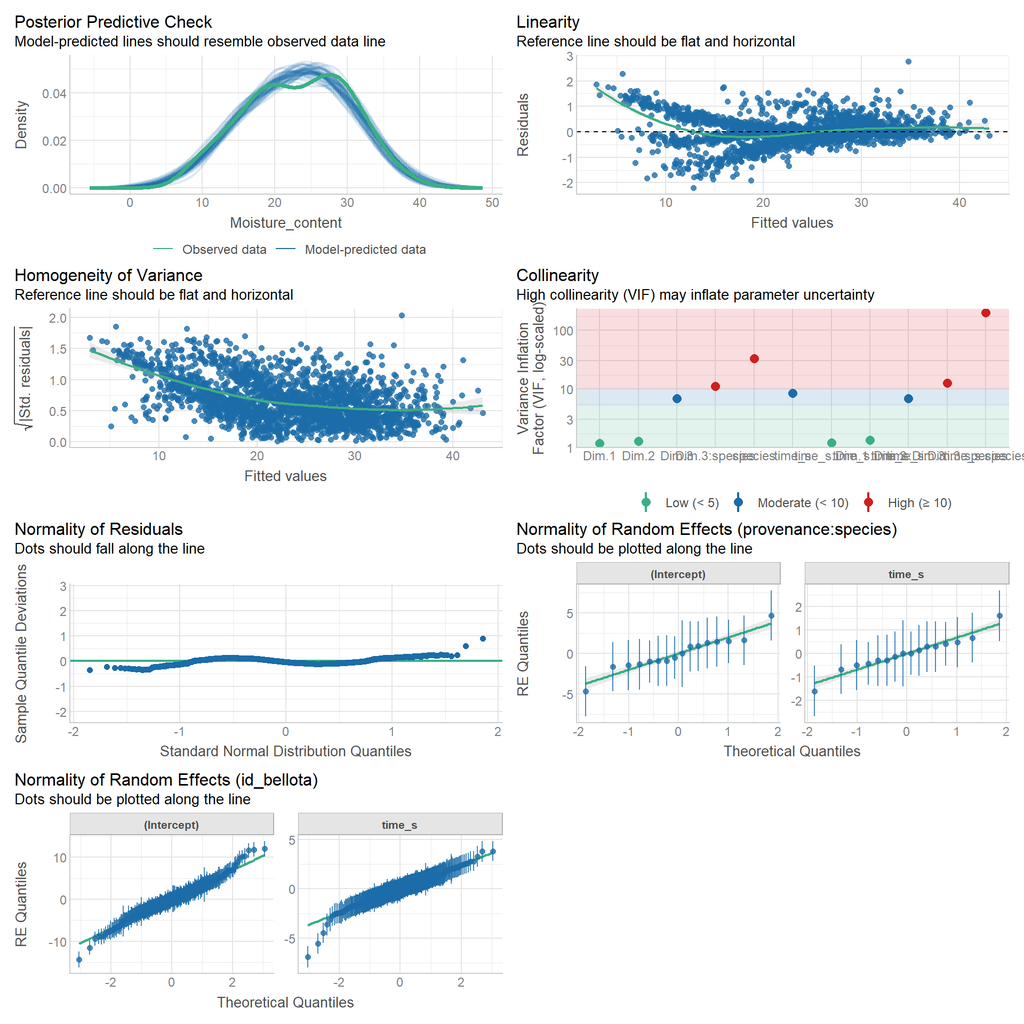

### Indices of model fit

| Metric | Value |
| --- | --- |
| AIC | 7764.8 |
| AICc | 7766.6 |
| BIC | 8010.4 |
| R2 (cond.) | 0.99 |
| R2 (marg.) | 0.68 |
| ICC | 0.98 |
| RMSE | 0.53 |
| Sigma | 0.66 |

For interpretation of performance metrics, please refer to [this documentation](https://easystats.github.io/performance/reference/model_performance.html).

# Parameter estimates

### Plot

[figure not shown]

### Tabular summary

Fixed Effects

| Parameter | Coefficient | SE | 95% CI | z | p |
| --- | --- | --- | --- | --- | --- |
| (Intercept) | 29.60 | 1.60 | (26.46, 32.74) | 18.47 | < .001 |
| time s | -8.23 | 0.56 | (-9.33, -7.14) | -14.71 | < .001 |
| Dim 1 | 0.59 | 0.16 | (0.29, 0.90) | 3.77 | < .001 |
| Dim 2 | -0.70 | 0.22 | (-1.13, -0.27) | -3.20 | 0.001 |
| Dim 3 | -1.56 | 0.52 | (-2.57, -0.55) | -3.03 | 0.002 |
| species (Quercus faginea) | -1.24 | 2.27 | (-5.70, 3.22) | -0.55 | 0.585 |
| species (Quercus ilex) | 2.48 | 2.06 | (-1.55, 6.51) | 1.21 | 0.228 |
| species (Quercus petraea) | -2.59 | 2.38 | (-7.26, 2.09) | -1.09 | 0.278 |
| species (Quercus pubescens) | -2.06 | 2.77 | (-7.50, 3.37) | -0.74 | 0.457 |
| species (Quercus pyrenaica) | -0.38 | 2.33 | (-4.95, 4.19) | -0.16 | 0.870 |
| species (Quercus robur) | 3.16 | 2.24 | (-1.22, 7.55) | 1.41 | 0.158 |
| species (Quercus suber) | -2.03 | 2.27 | (-6.49, 2.43) | -0.89 | 0.372 |
| time s × Dim 1 | 0.35 | 0.06 | (0.23, 0.47) | 5.78 | < .001 |
| time s × Dim 2 | -0.03 | 0.09 | (-0.20, 0.13) | -0.38 | 0.707 |
| time s × Dim 3 | -0.23 | 0.20 | (-0.62, 0.15) | -1.18 | 0.239 |
| time s × species (Quercus faginea) | 1.03 | 0.80 | (-0.53, 2.59) | 1.29 | 0.197 |
| time s × species (Quercus ilex) | 0.88 | 0.72 | (-0.53, 2.28) | 1.22 | 0.221 |
| time s × species (Quercus petraea) | -1.05 | 0.84 | (-2.71, 0.60) | -1.25 | 0.213 |
| time s × species (Quercus pubescens) | 0.87 | 0.97 | (-1.03, 2.77) | 0.90 | 0.369 |
| time s × species (Quercus pyrenaica) | 1.15 | 0.82 | (-0.45, 2.76) | 1.41 | 0.160 |
| time s × species (Quercus robur) | 2.20 | 0.78 | (0.67, 3.73) | 2.82 | 0.005 |
| time s × species (Quercus suber) | -1.27 | 0.80 | (-2.83, 0.29) | -1.60 | 0.110 |
| Dim 3 × species (Quercus faginea) | 1.45 | 0.90 | (-0.31, 3.20) | 1.61 | 0.106 |
| Dim 3 × species (Quercus ilex) | 1.40 | 0.76 | (-0.09, 2.88) | 1.84 | 0.066 |
| Dim 3 × species (Quercus petraea) | 1.68 | 0.72 | (0.26, 3.10) | 2.32 | 0.020 |
| Dim 3 × species (Quercus pubescens) | 2.80 | 0.88 | (1.07, 4.52) | 3.17 | 0.002 |
| Dim 3 × species (Quercus pyrenaica) | 0.54 | 0.77 | (-0.97, 2.05) | 0.70 | 0.482 |
| Dim 3 × species (Quercus robur) | 2.38 | 0.80 | (0.81, 3.96) | 2.96 | 0.003 |
| Dim 3 × species (Quercus suber) | 1.94 | 0.82 | (0.34, 3.55) | 2.38 | 0.017 |
| (time s × Dim 3) × species (Quercus faginea) | 0.78 | 0.35 | (0.10, 1.46) | 2.25 | 0.024 |
| (time s × Dim 3) × species (Quercus ilex) | -0.02 | 0.29 | (-0.59, 0.55) | -0.06 | 0.954 |
| (time s × Dim 3) × species (Quercus petraea) | 0.23 | 0.28 | (-0.32, 0.78) | 0.81 | 0.415 |
| (time s × Dim 3) × species (Quercus pubescens) | 0.66 | 0.34 | (-2.78e-03, 1.33) | 1.95 | 0.051 |
| (time s × Dim 3) × species (Quercus pyrenaica) | 0.50 | 0.30 | (-0.09, 1.08) | 1.67 | 0.095 |
| (time s × Dim 3) × species (Quercus robur) | 0.22 | 0.31 | (-0.39, 0.83) | 0.71 | 0.478 |
| (time s × Dim 3) × species (Quercus suber) | 0.15 | 0.32 | (-0.47, 0.77) | 0.47 | 0.640 |

Random Effects

| Parameter | Coefficient |
| --- | --- |
| SD (Intercept: provenance:species) | 2.10 |
| SD (Intercept: id_bellota) | 3.57 |
| SD (time_s: provenance:species) | 0.72 |
| SD (time_s: id_bellota) | 1.32 |
| Cor (Intercept~time_s: provenance:species) | -0.65 |
| Cor (Intercept~time_s: id_bellota) | -0.07 |
| SD (Residual) | 0.66 |

To find out more about table summary options, please refer to [this documentation](https://easystats.github.io/parameters/reference/model_parameters.html).

# Predicted Values

### Plot

[output not shown]

# Text reports

### Textual summary

We fitted a linear mixed model (estimated using ML and nlminb optimizer) to predict Moisture_content with time_s, Dim.1, Dim.2, Dim.3 and species (formula: Moisture_content ~ time_s * (Dim.1 + Dim.2 + Dim.3) + time_s * Dim.3 * species). The model included time_s as random effects (formula: list(~time_s | provenance:species, ~time_s | id_bellota)). The model’s total explanatory power is substantial (conditional R2 = 0.99) and the part related to the fixed effects alone (marginal R2) is of 0.68. The model’s intercept, corresponding to time_s = 0, Dim.1 = 0, Dim.2 = 0, Dim.3 = 0 and species = Quercus coccifera, is at 29.60 (95% CI (26.46, 32.74), p < .001). Within this model:

- The effect of time s is statistically significant and negative (beta = -8.23, 95% CI (-9.33, -7.14), p < .001)
- The effect of Dim 1 is statistically significant and positive (beta = 0.59, 95% CI (0.29, 0.90), p < .001)
- The effect of Dim 2 is statistically significant and negative (beta = -0.70, 95% CI (-1.13, -0.27), p = 0.001)
- The effect of Dim 3 is statistically significant and negative (beta = -1.56, 95% CI (-2.57, -0.55), p = 0.002)
- The effect of species (Quercus faginea) is statistically non-significant and negative (beta = -1.24, 95% CI (-5.70, 3.22), p = 0.585)
- The effect of species (Quercus ilex) is statistically non-significant and positive (beta = 2.48, 95% CI (-1.55, 6.51), p = 0.228)
- The effect of species (Quercus petraea) is statistically non-significant and negative (beta = -2.59, 95% CI (-7.26, 2.09), p = 0.278)
- The effect of species (Quercus pubescens) is statistically non-significant and negative (beta = -2.06, 95% CI (-7.50, 3.37), p = 0.457)
- The effect of species (Quercus pyrenaica) is statistically non-significant and negative (beta = -0.38, 95% CI (-4.95, 4.19), p = 0.870)
- The effect of species (Quercus robur) is statistically non-significant and positive (beta = 3.16, 95% CI (-1.22, 7.55), p = 0.158)
- The effect of species (Quercus suber) is statistically non-significant and negative (beta = -2.03, 95% CI (-6.49, 2.43), p = 0.372)
- The effect of time s × Dim 1 is statistically significant and positive (beta = 0.35, 95% CI (0.23, 0.47), p < .001)
- The effect of time s × Dim 2 is statistically non-significant and negative (beta = -0.03, 95% CI (-0.20, 0.13), p = 0.707)
- The effect of time s × Dim 3 is statistically non-significant and negative (beta = -0.23, 95% CI (-0.62, 0.15), p = 0.239)
- The effect of time s × species (Quercus faginea) is statistically non-significant and positive (beta = 1.03, 95% CI (-0.53, 2.59), p = 0.197)
- The effect of time s × species (Quercus ilex) is statistically non-significant and positive (beta = 0.88, 95% CI (-0.53, 2.28), p = 0.221)
- The effect of time s × species (Quercus petraea) is statistically non-significant and negative (beta = -1.05, 95% CI (-2.71, 0.60), p = 0.213)
- The effect of time s × species (Quercus pubescens) is statistically non-significant and positive (beta = 0.87, 95% CI (-1.03, 2.77), p = 0.369)
- The effect of time s × species (Quercus pyrenaica) is statistically non-significant and positive (beta = 1.15, 95% CI (-0.45, 2.76), p = 0.160)
- The effect of time s × species (Quercus robur) is statistically significant and positive (beta = 2.20, 95% CI (0.67, 3.73), p = 0.005)
- The effect of time s × species (Quercus suber) is statistically non-significant and negative (beta = -1.27, 95% CI (-2.83, 0.29), p = 0.110)
- The effect of Dim 3 × species (Quercus faginea) is statistically non-significant and positive (beta = 1.45, 95% CI (-0.31, 3.20), p = 0.106)
- The effect of Dim 3 × species (Quercus ilex) is statistically non-significant and positive (beta = 1.40, 95% CI (-0.09, 2.88), p = 0.066)
- The effect of Dim 3 × species (Quercus petraea) is statistically significant and positive (beta = 1.68, 95% CI (0.26, 3.10), p = 0.020)
- The effect of Dim 3 × species (Quercus pubescens) is statistically significant and positive (beta = 2.80, 95% CI (1.07, 4.52), p = 0.002)
- The effect of Dim 3 × species (Quercus pyrenaica) is statistically non-significant and positive (beta = 0.54, 95% CI (-0.97, 2.05), p = 0.482)
- The effect of Dim 3 × species (Quercus robur) is statistically significant and positive (beta = 2.38, 95% CI (0.81, 3.96), p = 0.003)
- The effect of Dim 3 × species (Quercus suber) is statistically significant and positive (beta = 1.94, 95% CI (0.34, 3.55), p = 0.017)
- The effect of (time s × Dim 3) × species (Quercus faginea) is statistically significant and positive (beta = 0.78, 95% CI (0.10, 1.46), p = 0.024)
- The effect of (time s × Dim 3) × species (Quercus ilex) is statistically non-significant and negative (beta = -0.02, 95% CI (-0.59, 0.55), p = 0.954)
- The effect of (time s × Dim 3) × species (Quercus petraea) is statistically non-significant and positive (beta = 0.23, 95% CI (-0.32, 0.78), p = 0.415)
- The effect of (time s × Dim 3) × species (Quercus pubescens) is statistically non-significant and positive (beta = 0.66, 95% CI (-2.78e-03, 1.33), p = 0.051)
- The effect of (time s × Dim 3) × species (Quercus pyrenaica) is statistically non-significant and positive (beta = 0.50, 95% CI (-0.09, 1.08), p = 0.095)
- The effect of (time s × Dim 3) × species (Quercus robur) is statistically non-significant and positive (beta = 0.22, 95% CI (-0.39, 0.83), p = 0.478)
- The effect of (time s × Dim 3) × species (Quercus suber) is statistically non-significant and positive (beta = 0.15, 95% CI (-0.47, 0.77), p = 0.640)

Standardized parameters were obtained by fitting the model on a standardized version of the dataset. 95% Confidence Intervals (CIs) and p-values were computed using a Wald z-distribution approximation. The model’s total explanatory power is substantial (conditional R2 = 0.99) and the part related to the fixed effects alone (marginal R2) is of 0.68

### Model information

|  | name | value |
| --- | --- | --- |
| 1 | is_binomial | FALSE |
| 2 | is_bernoulli | FALSE |
| 3 | is_count | FALSE |
| 4 | is_poisson | FALSE |
| 5 | is_negbin | FALSE |
| 6 | is_beta | FALSE |
| 7 | is_betabinomial | FALSE |
| 8 | is_orderedbeta | FALSE |
| 9 | is_dirichlet | FALSE |
| 10 | is_exponential | FALSE |

[output cut: 198 more lines]

````r
---
title: "Regression model summary from `{easystats}`"
output:
  flexdashboard::flex_dashboard:
    theme:
      version: 4
      # bg: "#101010"
      # fg: "#FDF7F7"
      primary: "#0054AD"
      base_font:
        google: Prompt
      code_font:
        google: JetBrains Mono
params:
  model: model
  check_model_args: check_model_args
  parameters_args: parameters_args
  performance_args: performance_args
---

```{r setup, include=FALSE}
library(flexdashboard)
library(easystats)

# Since not all regression model are supported across all packages, make the
# dashboard chunks more fault-tolerant. E.g. a model might be supported in
# `{parameters}`, but not in `{report}`.
#
# For this reason, `error = TRUE`
knitr::opts_chunk$set(
  error = TRUE,
  out.width = "100%"
)

# helper function for printing `{report}` outputs
bracket_to_parantheses <- function(text) {
  gsub("]", ")", gsub("[", "(", text, fixed = TRUE), fixed = TRUE)
}
```

```{r easydashboard-1}
# Get user-specified model data
model <- params$model

# Is it supported by `{easystats}`? Skip evaluation of the following chunks if not.
is_supported <- insight::is_model_supported(model)

if (!is_supported) {
  unsupported_message <- sprintf(
    "Unfortunately, objects of class `%s` are not yet supported in {easystats}.\n
    For a list of supported models, see `insight::supported_models()`.",
    class(model)[1]
  )
}
```


Model fit
=====================================

Column {data-width=700}
-----------------------------------------------------------------------

### Assumption checks

```{r check-model, eval=is_supported, fig.height=10, fig.width=10}
check_model_args <- c(list(model), params$check_model_args)
# add verbose, if not done yet
if (is.null(check_model_args$verbose)) check_model_args$verbose <- FALSE
tryCatch(
  {
    do.call(performance::check_model, check_model_args)
  },
  error = function(e) {
    cat(insight::format_message(
      "\nSomething did not work as expected. Please file an issue at {.url https://github.com/easystats/easystats/issues/} and post the following output:",
      paste0("\n`", e$message, "`")
    ))
  }
)
```

```{r easydashboard-2, eval=!is_supported}
cat(unsupported_message)
```

Column {data-width=300}
-----------------------------------------------------------------------

### Indices of model fit

```{r easydashboard-3, eval=is_supported}
# {performance}
performance_args <- c(list(model), params$performance_args)
# add verbose, if not done yet
if (is.null(performance_args$verbose)) performance_args$verbose <- FALSE
table_performance <- do.call(performance::performance, performance_args)
print_md(table_performance, layout = "vertical", caption = NULL)
```


```{r easydashboard-4, eval=!is_supported}
cat(unsupported_message)
```

For interpretation of performance metrics, please refer to <a href="https://easystats.github.io/performance/reference/model_performance.html" target="_blank">this documentation</a>.

Parameter estimates
=====================================

Column {data-width=550}
-----------------------------------------------------------------------

### Plot

```{r dot-whisker, eval=is_supported}
# `{parameters}`
parameters_args <- c(list(model), params$parameters_args)
# add verbose, if not done yet
if (is.null(parameters_args$verbose)) parameters_args$verbose <- FALSE
table_parameters <- do.call(parameters::parameters, parameters_args)

plot(table_parameters)
```


```{r easydashboard-5, eval=!is_supported}
cat(unsupported_message)
```

Column {data-width=450}
-----------------------------------------------------------------------

### Tabular summary

```{r easydashboard-6, eval=is_supported}
print_md(table_parameters, caption = NULL)
```


```{r easydashboard-7, eval=!is_supported}
cat(unsupported_message)
```

To find out more about table summary options, please refer to <a href="https://easystats.github.io/parameters/reference/model_parameters.html" target="_blank">this documentation</a>.


Predicted Values
=====================================

Column {data-width=600}
-----------------------------------------------------------------------

### Plot

```{r expected-values, eval=is_supported, fig.height=10, fig.width=10}
# {modelbased}
int_terms <- find_interactions(model, component = "conditional", flatten = TRUE)
con_terms <- find_variables(model)$conditional

if (is.null(int_terms)) {
  model_terms <- con_terms
} else {
  model_terms <- clean_names(int_terms)
  int_terms <- unique(unlist(strsplit(clean_names(int_terms), ":", fixed = TRUE)))
  model_terms <- c(model_terms, setdiff(con_terms, int_terms))
}

text_modelbased <- tryCatch(
  {
    lapply(unique(model_terms), function(i) {
      estimate_means(model, by = i, verbose = FALSE)
    })
  },
  error = function(e) {
    cat(insight::format_message(
      "\nSomething did not work as expected. Please file an issue at {.url https://github.com/easystats/easystats/issues/} and post the following output:",
      paste0("\n`", e$message, "`")
    ))
    NULL
  }
)

if (!is.null(text_modelbased)) {
  ggplot2::theme_set(theme_modern())
  # all_plots <- lapply(text_modelbased, function(i) {
  #   out <- do.call(visualisation_recipe, c(list(i), modelbased_args))
  #   plot(out) + ggplot2::ggtitle("")
  # })
  all_plots <- lapply(text_modelbased, function(i) {
    out <- visualisation_recipe(i, join_dots = FALSE, show_data = FALSE)
    plot(out) + ggplot2::ggtitle("")
  })

  see::plots(all_plots, n_columns = round(sqrt(length(text_modelbased))))
}
```


```{r easydashboard-8, eval=!is_supported}
cat(unsupported_message)
```

Column {data-width=400}
-----------------------------------------------------------------------

### Tabular summary

```{r easydashboard-9, eval=is_supported, results="asis"}
if (!is.null(text_modelbased)) {
  for (i in text_modelbased) {
    tmp <- print_md(i)
    tmp[length(tmp)] <- paste(insight::compact_character(strsplit(tmp[length(tmp)], "\n")[[1]]), collapse = "; ")
    print(tmp)
  }
}
```


```{r easydashboard-10, eval=!is_supported}
cat(unsupported_message)
```


Text reports
=====================================

Column {data-width=500}
-----------------------------------------------------------------------

### Textual summary

```{r easydashboard-11, eval=is_supported, results='asis', collapse=TRUE}
# {report}
text_report <- tryCatch(
  {
    report(model, verbose = FALSE)
  },
  error = function(e) {
    cat(insight::format_message(
      "\nSomething did not work as expected. Please file an issue at {.url https://github.com/easystats/easystats/issues/} and post the following output:",
      paste0("\n`", e$message, "`")
    ))
    NULL
  }
)


text_report_performance <- tryCatch(
  {
    report_performance(model, verbose = FALSE)
  },
  error = function(e) {
    cat(insight::format_message(
      "\nSomething did not work as expected. Please file an issue at {.url https://github.com/easystats/easystats/issues/} and post the following output:",
      paste0("\n`", e$message, "`")
    ))
    NULL
  }
)

if (!is.null(text_report)) {
  cat(bracket_to_parantheses(text_report))
  cat("\n")
}

if (!is.null(text_report_performance)) {
  cat(bracket_to_parantheses(text_report_performance))
}
```


```{r easydashboard-12, eval=!is_supported}
cat(unsupported_message)
```

Column {data-width=500}
-----------------------------------------------------------------------

### Model information

```{r easydashboard-13, eval=is_supported}
model_info_data <- insight::model_info(model, verbose = FALSE)
model_info_data <- datawizard::data_to_long(as.data.frame(insight::compact_list(model_info_data)))

DT::datatable(model_info_data)
```

```{r easydashboard-14, eval=!is_supported}
cat(unsupported_message)
```
````